# notebook_Visualizing Inequalities in Life Expectancy

Pierre-Etienne TOULEMONDE

2022-12-15

# 1 United Nations life expectancy

Tags: Data manipulation, Data visualization, Importing & cleaning data

Principal packages: dplyr, tidyr, ggplot2

Life expectancy at birth is a measure of the average a living being is expected to live. It takes into account several demographic factors like gender, country, or year of birth.

Life expectancy at birth can vary along time or between countries because of many causes: the evolution of medicine, the degree of development of countries, or the effect of armed conflicts. Life expectancy varies between gender, as well. The data shows that women live longer that men. Why? Several potential factors, including biological reasons and the theory that women tend to be more health conscious.

Let’s create some plots to explore the inequalities about life expectancy at birth around the world. We will use a dataset from the United Nations Statistics Division, which is available [here](http://data.un.org/Data.aspx?d=GenderStat&f=inID:37&c=1,2,3,4,5,6&s=crEngName:asc,sgvEngName:asc,timeEngName:desc&v=1).

This project is a project proposed on the Datacamp website, which I did as part of my training.

## 1.1 Data

```r
# This sets plot images to a nice size
options(repr.plot.width = 6, repr.plot.height = 6)

# Loading packages
library(dplyr)
library(tidyr)
library(ggplot2)

# Loading data
life_expectancy <- read.csv("datasets/UNdata.csv")

# Taking a look at the first few rows
head(life_expectancy)
```

```
##   Country.or.Area Subgroup      Year
## 1     Afghanistan   Female 2000-2005
## 2     Afghanistan   Female 1995-2000
## 3     Afghanistan   Female 1990-1995
## 4     Afghanistan   Female 1985-1990
## 5     Afghanistan     Male 2000-2005
## 6     Afghanistan     Male 1995-2000
##                                                          Source  Unit Value
## 1 UNPD_World Population Prospects_2006 (International estimate) Years    42
## 2 UNPD_World Population Prospects_2006 (International estimate) Years    42
## 3 UNPD_World Population Prospects_2006 (International estimate) Years    42
## 4 UNPD_World Population Prospects_2006 (International estimate) Years    41
## 5 UNPD_World Population Prospects_2006 (International estimate) Years    42
## 6 UNPD_World Population Prospects_2006 (International estimate) Years    42
##   Value.Footnotes
## 1              NA
## 2              NA
## 3              NA
## 4              NA
## 5              NA
## 6              NA
```

## 1.2 Life expectancy of men vs. women by country

To familiarise ourselves with our data, the aim is to represent the average life expectancy of men and women in all countries for the latest recorded period (2000-2005). For this purpose, a scatter plot is a useful way of visualising the relationship between two variables. It is a simple graph in which points are arranged on two axes, each representing one of the variables. The x-axis is the life expectancy of men, and the y-axis is the life expectancy of women.

```r
# Subsetting and reshaping the life expectancy data
subdata <- life_expectancy  %>%
    filter(Year == "2000-2005") %>%
    select(Country.or.Area, Subgroup, Value) %>%
    spread(key = Subgroup, value = Value)

# Taking a look at the first few rows
head(subdata)
```

```
##   Country.or.Area Female Male
## 1     Afghanistan     42   42
## 2         Albania     79   73
## 3         Algeria     72   70
## 4          Angola     43   39
## 5       Argentina     78   71
## 6         Armenia     75   68
```

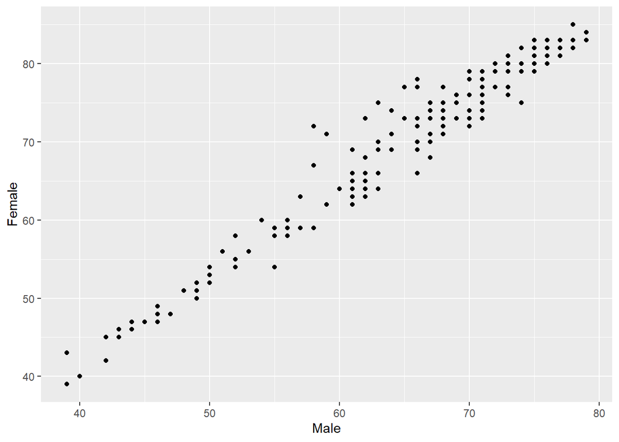

```r
# Plotting male and female life expectancy
ggplot(subdata, aes(x= Male, y = Female)) +
    geom_point()
```

## 1.3 Study of inter-country dispersion

A good plot must be easy to understand. Starting from the previous plot, let’s set the same limits for both axes as well as place a diagonal line for reference. After doing this, the difference between men and women across countries will be easier to interpret.

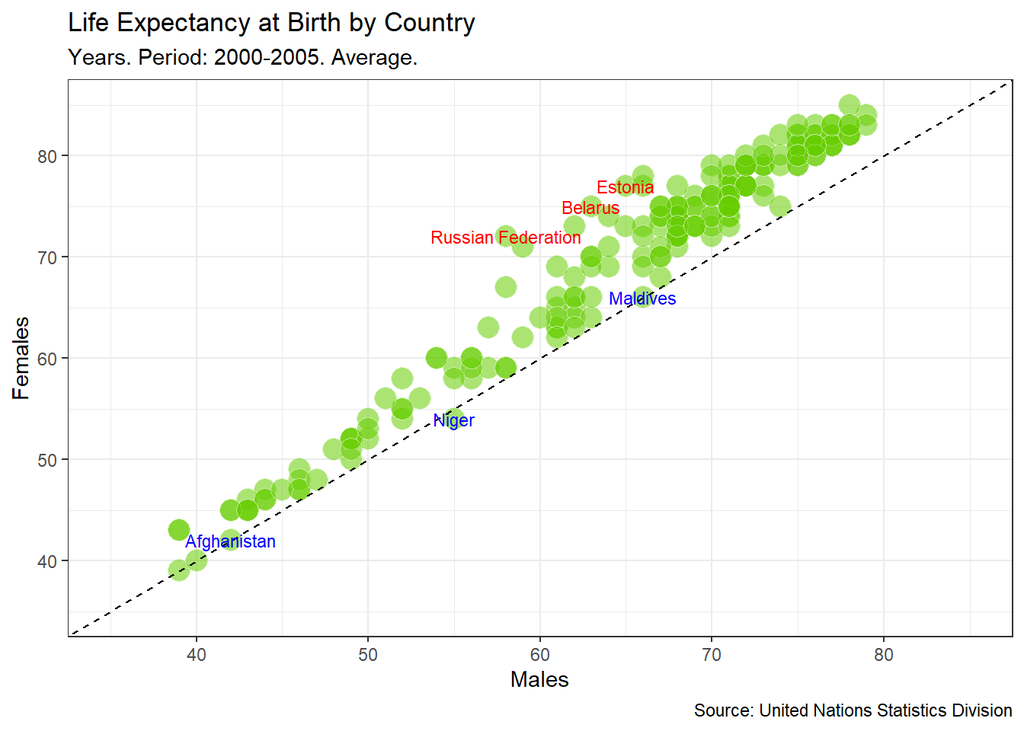

```r
top_male <- subdata %>%
    arrange(Male-Female) %>%
    head(3)
top_female <- subdata %>%
    arrange(Female-Male) %>%
    head(3)

# Adding text to the previous plot to label countries of interest
ggplot(subdata, aes(x = Male, y = Female, label = Country.or.Area)) +
  geom_point(colour="white", fill="chartreuse3", shape=21, alpha=.55, size=5)+
  geom_abline(intercept = 0, slope = 1, linetype=2)+
  scale_x_continuous(limits=c(35,85))+
  scale_y_continuous(limits=c(35,85))+
  labs(title="Life Expectancy at Birth by Country",
       subtitle="Years. Period: 2000-2005. Average.",
       caption="Source: United Nations Statistics Division",
       x="Males",
       y="Females") +
  geom_text(data=top_male, size=3, color = "red") +
  geom_text(data=top_female, size=3, color = "blue") +
  theme_bw()
```

In blue, we see the top 3 countries where men’s life expectancy is higher than women’s. In red, we see the top 3 countries where women’s life expectancy is higher than men’s.

## 1.4 How has life expectancy by gender evolved?

Since our data contains historical information, let’s see now how life expectancy has evolved in recent years. Our second plot will represent the difference between men and women across countries between two periods: 2000-2005 and 1985-1990.

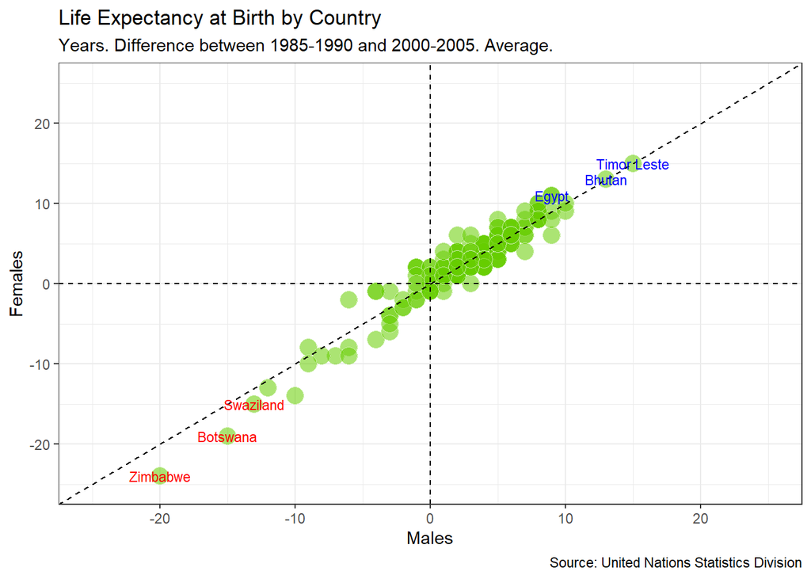

```r
# Subsetting, mutating and reshaping the life expectancy data
subdata2 <- life_expectancy %>%
  filter(Year %in% c("1985-1990", "2000-2005")) %>%
  mutate(Sub_Year=paste(Subgroup, Year, sep="_")) %>%
  mutate(Sub_Year=gsub("-", "_", Sub_Year)) %>%
  select(-Subgroup, -Year) %>%
  spread(Sub_Year, Value) %>%
  mutate(diff_Female = Female_2000_2005 - Female_1985_1990,
         diff_Male   = Male_2000_2005 - Male_1985_1990)

# Subseting data to obtain countries of interest
top <- subdata2 %>% arrange(diff_Male+diff_Female) %>% head(3)
bottom <- subdata2 %>% arrange(-(diff_Male+diff_Female)) %>% head(3)

# Adding text to the previous plot to label countries of interest
ggplot(subdata2, aes(x=diff_Male, y=diff_Female, label=Country.or.Area), guide=FALSE)+
  geom_point(colour="white", fill="chartreuse3", shape=21, alpha=.55, size=5)+
  geom_abline(intercept = 0, slope = 1, linetype=2)+
  scale_x_continuous(limits=c(-25,25))+
  scale_y_continuous(limits=c(-25,25))+
  geom_hline(yintercept=0, linetype=2)+
  geom_vline(xintercept=0, linetype=2)+
  labs(title="Life Expectancy at Birth by Country",
       subtitle="Years. Difference between 1985-1990 and 2000-2005. Average.",
       caption="Source: United Nations Statistics Division",
       x="Males",
       y="Females")+
  geom_text(data = top, size = 3, color = "red") +
  geom_text(data = bottom, size = 3, color = "blue")+
  theme_bw()
```

The countries in blue are the countries where life expectancy increased the most between the 2 periods, and in red the countries where life expectancy decreased the most.

# 2 Session

```r
print( paste0( "System version : ", sessionInfo()$running, ", ", sessionInfo()$platform) )
```

```
## [1] "System version : Windows 10 x64 (build 19045), x86_64-w64-mingw32/x64 (64-bit)"
```

```r
print( paste0( R.version$version.string, " - ", R.version$nickname ) )
```

```
## [1] "R version 4.2.0 (2022-04-22 ucrt) - Vigorous Calisthenics"
```

```r
for (package in c( sessionInfo()$basePkgs, objects(sessionInfo()$otherPkgs) ) ) {
  print( paste0( package, " : ", package, "_", packageVersion(package) ) ) }
```

```
## [1] "stats : stats_4.2.0"
## [1] "graphics : graphics_4.2.0"
## [1] "grDevices : grDevices_4.2.0"
## [1] "utils : utils_4.2.0"
## [1] "datasets : datasets_4.2.0"
## [1] "methods : methods_4.2.0"
## [1] "base : base_4.2.0"
## [1] "dplyr : dplyr_1.0.10"
## [1] "ggplot2 : ggplot2_3.4.0"
## [1] "tidyr : tidyr_1.2.1"
```